# Seguros_Final

Beltran Aller Lopez

24/11/2019

# LIBRARIES

```r
library(readr)
library(tidyverse)
library(dummies)
```

# DATA

```r
seguros <- read_delim("../data/EPF2018_segurosalud.csv",
    ";", escape_double = FALSE, col_types = cols(ESTUDREDSP = col_character(),
        NMIEM2 = col_number(), NMIEMB = col_number(),
        OCUSP = col_character(), REGTEN = col_character(),
        SEXOSP = col_character(), SUPERF = col_number(),
        TAMAMU = col_character(), TIPHOGAR3 = col_character()),
    trim_ws = TRUE)
seguros <- as.data.frame(seguros)
View(seguros)
```

En un primer momento se puede pensar que el año de concesión del seguro no tiene importancia, esto puede no ser así. Depende de la existencia de varias valores para el año, en caso de haber distintos valores, este podría tener significación, aunque no lo sabemos. Procedo a mirar el número de años distintos del dataset.

```r
unique(seguros$ANOENC)
```

```
## [1] 2018
```

Únicamente tenemos seguros que han sido concedidos en el 2018, por tanto en este aspecto las observaciones son todas homogéneas y la variables no nos aporta información, la elimino del dataset.

```r
seguros$ANOENC <- NULL
```

Se observa también la existencia de una variable que sirve a modo de index, ‘NUMERO’, esta tampoco tiene relevancia. La elimino.

```r
seguros$NUMERO <- NULL
```

Transformo la variable ‘SUPERF’ creando 4 rangos en funicón de la superficie de la casa.

```r
for (i in seq(length(seguros$SUPERF))) {
    if (seguros$SUPERF[i] > 0 & seguros$SUPERF[i]  <= 35) {
        seguros$SUPERF[i] = 1
    }
    else if (seguros$SUPERF[i] > 35 & seguros$SUPERF[i] <= 299) {
        seguros$SUPERF[i] = 2
    }
    else if (seguros$SUPERF[i] >= 300) {
        seguros$SUPERF[i] = 3
    }
    else {
        seguros$SUPERF[i] = -9 # este seria el caso en que no constase la superficie de la vivienda, esto nos importa y lo codificamos tambien
    }
}
```

Tipifico como numéricas ciertas variables. Las variables ordinales, tales como los niveles de ingresos o el nivel de estudios no serán transformadas en dummies, las dejo como numéricas, puesto que ya poseen una estructura subyacente y el incremento de estas tiene un significado de por sí. Sabemos que a medida que se incrementa el valor de las variables, los ingresos y los estudios son mayores.

```r
seguros$TIPHOGAR3 <- as.numeric(seguros$TIPHOGAR3)
seguros$NUMOCUP <- as.numeric(seguros$NUMOCUP)
seguros$TAMAMU <- as.numeric(seguros$TAMAMU)
seguros$ESTUDREDSP <- as.numeric(seguros$ESTUDREDSP)
seguros$OCUSP <- as.numeric(seguros$OCUSP)
seguros$INTERINPSP <- as.numeric(seguros$INTERINPSP)
seguros$REGTEN <- as.numeric(seguros$REGTEN)
seguros$INTERIN <- as.numeric(seguros$INTERIN)
seguros$SEXOSP <- as.factor(seguros$SEXOSP)
```

Elimino las observaciones que presentan valores omitidos.

```r
seguros <- na.omit(seguros)
seguros <- subset(seguros, seguros$NUMOCUP >= 0 & seguros$TIPHOGAR3 >= 0 & seguros$SUPERF >= 0 & seguros$INTERINPSP >= 0)
```

Recodifico también el régimen de tenencia del hogar, de 6 tipos pasamos a únicamente 3.

```r
seguros$REGTEN[seguros$REGTEN == 1 | seguros$REGTEN == 2] <- 1
seguros$REGTEN[seguros$REGTEN == 3 | seguros$REGTEN == 4] <- 2
seguros$REGTEN[seguros$REGTEN == 5 | seguros$REGTEN == 6] <- 3
```

El tipo de hogar también será recodificado, pasando así de 12 posibles hogares a únicamente 5.

```r
seguros$TIPHOGAR3[seguros$TIPHOGAR3 == 1 | seguros$TIPHOGAR3 == 2 | seguros$TIPHOGAR3 == 3 | seguros$TIPHOGAR3 == 4] <- 1
seguros$TIPHOGAR3[seguros$TIPHOGAR3 == 5 | seguros$TIPHOGAR3 == 6] <- 2
seguros$TIPHOGAR3[seguros$TIPHOGAR3 == 7 | seguros$TIPHOGAR3 == 8 | seguros$TIPHOGAR3 == 9] <- 3
seguros$TIPHOGAR3[seguros$TIPHOGAR3 == 10 | seguros$TIPHOGAR3 == 11] <- 4
seguros$TIPHOGAR3[seguros$TIPHOGAR3 == 12] <- 5
```

```r
seguros$Seguro_salud <- factor(seguros$Seguro_salud, levels = c(0,1), labels = c('Sin seguro', 'Con seguro'))
```

```r
summary(seguros)
```

```
##      Seguro_salud       TAMAMU          NMIEMB           NMIEM2
##  Sin seguro:18175   Min.   :1.000   Min.   : 1.000   Min.   :0.0000
##  Con seguro: 1845   1st Qu.:1.000   1st Qu.: 2.000   1st Qu.:0.0000
##                     Median :3.000   Median : 2.000   Median :0.0000
##                     Mean   :2.706   Mean   : 2.602   Mean   :0.3705
##                     3rd Qu.:4.000   3rd Qu.: 3.000   3rd Qu.:0.0000
##                     Max.   :5.000   Max.   :11.000   Max.   :7.0000
##     NUMOCUP        TIPHOGAR3         EDADSP      SEXOSP      ESTUDREDSP
##  Min.   :0.000   Min.   :1.000   Min.   :19.00   1:13505   Min.   :1.000
##  1st Qu.:0.000   1st Qu.:1.000   1st Qu.:45.00   6: 6515   1st Qu.:2.000
##  Median :1.000   Median :2.000   Median :55.00             Median :3.000
##  Mean   :1.029   Mean   :2.357   Mean   :56.48             Mean   :2.647
##  3rd Qu.:2.000   3rd Qu.:3.000   3rd Qu.:68.00             3rd Qu.:4.000
##  Max.   :6.000   Max.   :4.000   Max.   :85.00             Max.   :4.000
##      OCUSP         INTERINPSP        REGTEN          SUPERF
##  Min.   :1.000   Min.   :1.000   Min.   :1.000   Min.   :1.000
##  1st Qu.:1.000   1st Qu.:2.000   1st Qu.:1.000   1st Qu.:2.000
##  Median :1.000   Median :3.000   Median :1.000   Median :2.000
##  Mean   :1.429   Mean   :3.379   Mean   :1.245   Mean   :2.009
##  3rd Qu.:2.000   3rd Qu.:4.000   3rd Qu.:1.000   3rd Qu.:2.000
##  Max.   :2.000   Max.   :7.000   Max.   :3.000   Max.   :3.000
##     INTERIN
##  Min.   : 1.000
##  1st Qu.: 3.000
##  Median : 4.000
##  Mean   : 4.452
##  3rd Qu.: 6.000
##  Max.   :10.000
```

Divimos el dataset en dos partes, una de entrenamiento y otra de validación, la proporción será de 70:30.

```r
set.seed(1234)
division <- sample(nrow(seguros), 0.7 * nrow(seguros))
entrenamiento <- seguros[division,]
validacion <- seguros[-division,]
```

```r
table(entrenamiento$Seguro_salud)
```

```
##
## Sin seguro Con seguro
##      12685       1329
```

```r
table(validacion$Seguro_salud)
```

```
##
## Sin seguro Con seguro
##       5490        516
```

A continuación procedo a la estimación del modelo logístico.

```r
modelo1 <- glm(entrenamiento$Seguro_salud~., data = entrenamiento, family = 'binomial')
summary(modelo1)
```

```
##
## Call:
## glm(formula = entrenamiento$Seguro_salud ~ ., family = "binomial",
##     data = entrenamiento)
##
## Deviance Residuals:
##     Min       1Q   Median       3Q      Max
## -1.4074  -0.4595  -0.3141  -0.2278   2.9999
##
## Coefficients:
##              Estimate Std. Error z value Pr(>|z|)
## (Intercept) -7.253696   0.463885 -15.637  < 2e-16 ***
## TAMAMU      -0.120993   0.020635  -5.864 4.53e-09 ***
## NMIEMB      -0.039339   0.050330  -0.782  0.43444
## NMIEM2       0.241190   0.059006   4.088 4.36e-05 ***
## NUMOCUP      0.070951   0.069053   1.027  0.30419
## TIPHOGAR3   -0.085122   0.040771  -2.088  0.03682 *
## EDADSP       0.023016   0.003704   6.215 5.14e-10 ***
## SEXOSP6      0.045010   0.069166   0.651  0.51521
## ESTUDREDSP   0.299650   0.036826   8.137 4.06e-16 ***
## OCUSP        0.060922   0.126510   0.482  0.63012
## INTERINPSP   0.223240   0.035058   6.368 1.92e-10 ***
## REGTEN      -0.075352   0.069460  -1.085  0.27800
## SUPERF       0.565176   0.181763   3.109  0.00187 **
## INTERIN      0.244612   0.032830   7.451 9.27e-14 ***
## ---
## Signif. codes:  0 '***' 0.001 '**' 0.01 '*' 0.05 '.' 0.1 ' ' 1
##
## (Dispersion parameter for binomial family taken to be 1)
##
##     Null deviance: 8789.0  on 14013  degrees of freedom
## Residual deviance: 7645.4  on 14000  degrees of freedom
## AIC: 7673.4
##
## Number of Fisher Scoring iterations: 6
```

Se observa que algunas variables, tales como el número d emiebos del hogar, el sexo, el número de miembros ocupados, el régimen de tenencia de la casa o si el sustentador principal se encontraba ocupado antes de la encuesta, no paracen tener relevancia en el modelo. a continuacón paso a observar los odd ratio e interpretarlos.

```r
exp(coef(modelo1))
```

```
##  (Intercept)       TAMAMU       NMIEMB       NMIEM2      NUMOCUP    TIPHOGAR3
## 0.0007075543 0.8860404804 0.9614251427 1.2727633774 1.0735283904 0.9184000167
##       EDADSP      SEXOSP6   ESTUDREDSP        OCUSP   INTERINPSP       REGTEN
## 1.0232833965 1.0460381243 1.3493869362 1.0628155352 1.2501207619 0.9274169137
##       SUPERF      INTERIN
## 1.7597578805 1.2771251389
```

El tamaño del municipio presenta un odd ratio inferior a 1, esto quiere decir que conforme se incrementa un punto esta variable, es decir, en nuestro caso se pasa de un municipio mayor a uno de menos habitantes, la probabilidad de tener un seguro de vida privado disminuye frente a no tenerlo.

Si se incrementa el número d ehijos menores de 14 años sucede al revés, la probabilidad de tener un seguro de vida `privado aumenta respecto a la de no tenerlo.

La edad afecta positivamente tambíen, a mayor edad, mayor probabilidad de tenerle frente a no tenerlo.

El nivel de estudios también afecta considerablemente, a medida que subimos en la categoría de nivel de estudios, es decir, la gente presenta niveles de estudios mayores, aumenta la probabilidad de poseer un seguro de vida privado frente a no poseerlo.

El nivel de ingresos del sustentador pricipal, así como el nivel de ingresos general de la familia, afectan a las probabilidades también. Según subimos en las distintas categorías de niveles de ingresos, se observan ingresos cada vez mayores, es mayor la probabilidad de tener un seguro de vida privado frente a no tenerlo.

La superficie de la vivienda se comporta también de la misma forma.

Un caso relevante es el tipo de hogar, si pasamos de un hogar unipersonal a un hogar en pareja sin hijos las probabilidades empeorean. Y si pasamos de uno en pareja sin hijos a uno en pareja con hijos aún más.

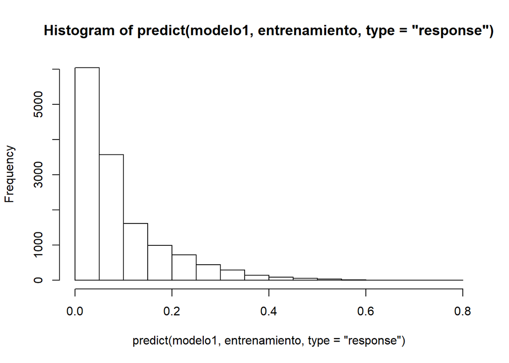

```r
hist(predict(modelo1, entrenamiento, type = "response"))
```

El gráfico anterior nos da una idea de donde podemos situar el punto de corte acorde a la distribución de las frecuencias en el set de entrenamiento. Lo situaré en 0.4.

Primero realizo la prueba en el set de entrenamiento.

```r
probalidad_entrenamiento <- predict(modelo1, entrenamiento, type = "response")
```

```r
logit.pred.entrenamiento <- factor(probalidad_entrenamiento > .4, levels = c(FALSE, TRUE), labels = c("Sin seguro", "Con seguro"))
```

```r
logit.perf.entrenamiento <- table(entrenamiento$Seguro_salud, logit.pred.entrenamiento, dnn = c("Actual", "Predicted"))
logit.perf.entrenamiento
```

```
##             Predicted
## Actual       Sin seguro Con seguro
##   Sin seguro      12567        118
##   Con seguro       1243         86
```

Se observa un accuracy del 90% para la parte de entrenamiento, a continuación realizaré lo mismo para la parte de validación, de esta forma compruebo si el modelo presenta overfitting.

```r
probalidad_validacion <- predict(modelo1, validacion, type = "response")
```

```r
logit.pred.validacion <- factor(probalidad_validacion > .4, levels = c(FALSE, TRUE), labels = c("Sin seguro", "Con seguro"))
```

```r
logit.perf.validacion <- table(validacion$Seguro_salud, logit.pred.validacion, dnn = c("Actual", "Predicted"))
logit.perf.validacion
```

```
##             Predicted
## Actual       Sin seguro Con seguro
##   Sin seguro       5431         59
##   Con seguro        477         39
```